# Week2Project

Sarah

9/20/2019

### Exploring the Three Data Sets (Twitter, Blog, and News)

Here’s a data table that shows the summary statistics for the character length of each of the data sets.

```
##      Data  Length max_char min_char mean_char median_char
## 1 Twitter 2360148      140        2  68.68045          64
## 2    News 1010242    11384        1 201.16285         185
## 3    Blog  899288    40833        1 229.98695         156
```

We can see that the Twitter data set has the most entries and the Blog data set has the longest entry with almost 41,000 characters.

You can see a bit more about the data by looking at the box plot of the word count.

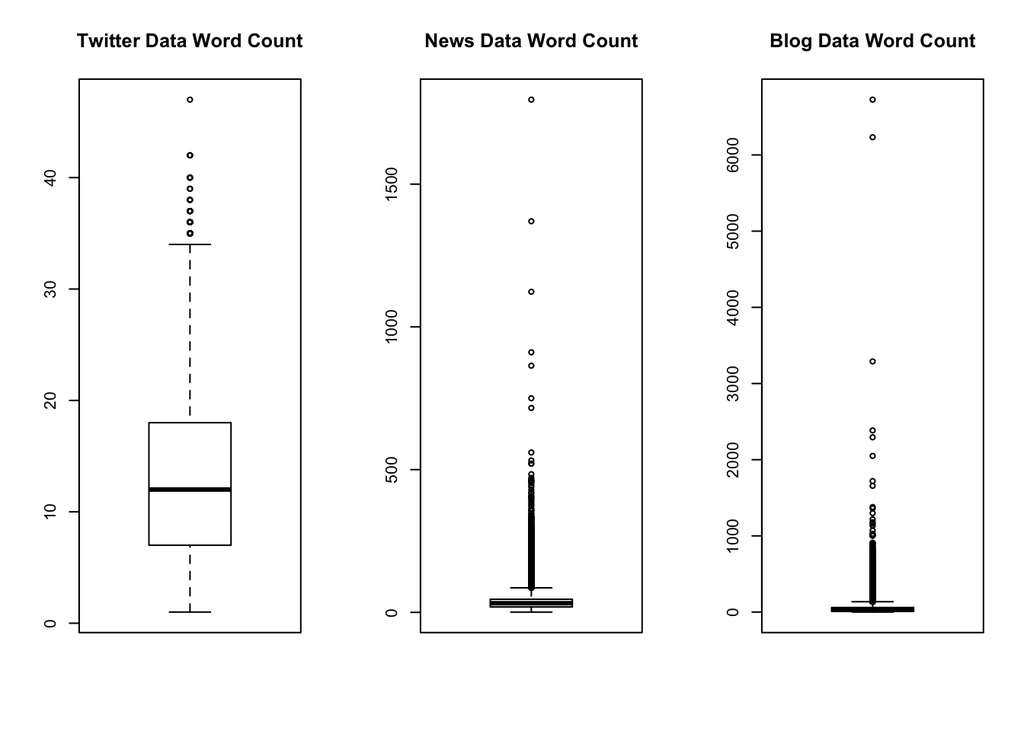

We can see that the twitter data set is much more compact (possibly because twitter limits the number of characters that can be used in a post). The other two are really squished.

### Further Exploring

I decided that for this portion of the exploratory analysis, I would look at 10,000 random lines from each of the different files and compare the top words from each resource.

Using Quanteda, I created tokens for each of the three data sets to create a dfm and a word cloud.

For this portion of the assignment I am using stem = TRUE, remove_numbers = FALSE, remove_punct = TRUE, remove_symbols = TRUE, remove_hyphens = TRUE

### Twitter Data

The sampled Twitter Data Set has 12239 words used, only those used at least 75 times are plotted in the word cloud.

The top ten features are:

```
##   get  just thank    go  like  love   day  good    rt  time
##   637   617   593   550   538   481   445   440   391   381
```

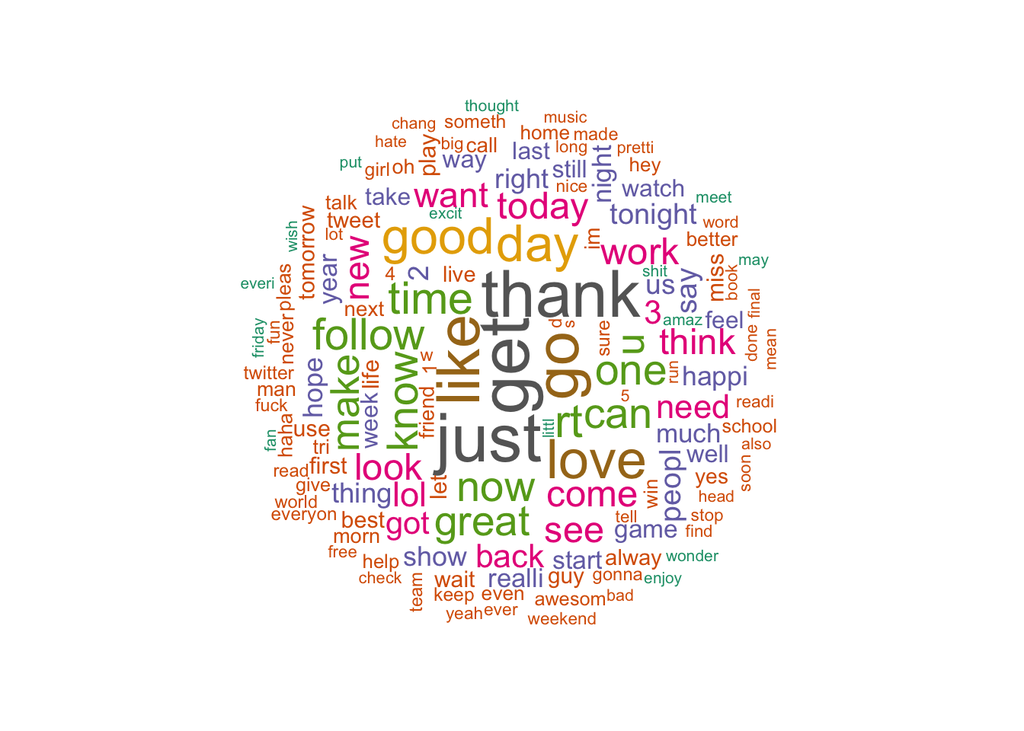

I found it interesting that “rt”" was used so frequently. I don’t use twitter enough to understand the frequency so I explored to see in which cases it was being used

```r
rt<-grep(" rt ",twitt)
head(twitt[rt])
```

```
## [1] "Nick has 2 get 2 WI & talk everywhere rt now 2 keep corrupt walker government from staying in power. Walker spouts the lies"
## [2] "it'll ply let my rt once"
## [3] "who? rt - Really? Ben on The Bachelor=Ho-hum! We want a NEW cutie we cn get excited about! Sloppy seconds=boring!"
## [4] "The only thing has to do is rt tweet and my life would be set! (: #guymahomie! (: and btw I'm goin to your online concert!:D"
## [5] "rstrnt & Hotel owners in South FL-when watching yr bottom line, thr R ways 2 save $$ rt away w/ no investment call 561.909.9902 for info"
## [6] "great... soo rt u yet and officially"
```

For my predictive algorithm in the future, I think I will keep these different word cases separate.

### News Data

The sampled News dataset has 21449 features The top ten are:

```
##  said  year   one   new  time state  like   two   get   say
##  2463  1245   891   743   734   664   634   613   611   596
```

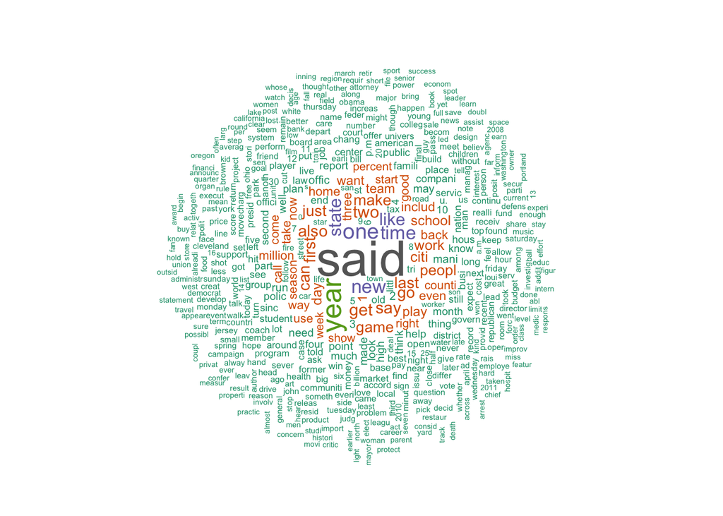

### Blog Data

The sampled Blog data set has 20615 features The top ten are:

```
##  one like just time  can  get   go make know  day
## 1513 1284 1156 1149 1118 1024  866  854  850  842
```

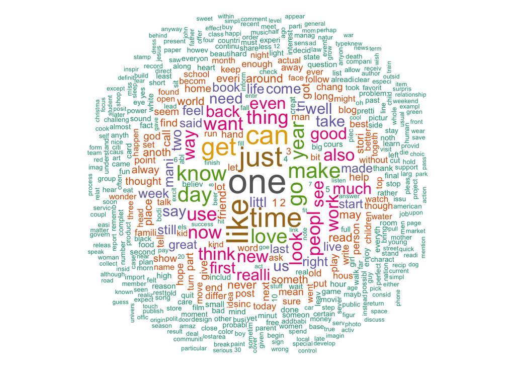

### Combined Data

There are 35849 total features in the combined dataset of twitter, blog, and news.

```
## said  one like just  get time year  can   go  day
## 2933 2767 2456 2305 2272 2264 2193 2038 1972 1737
```

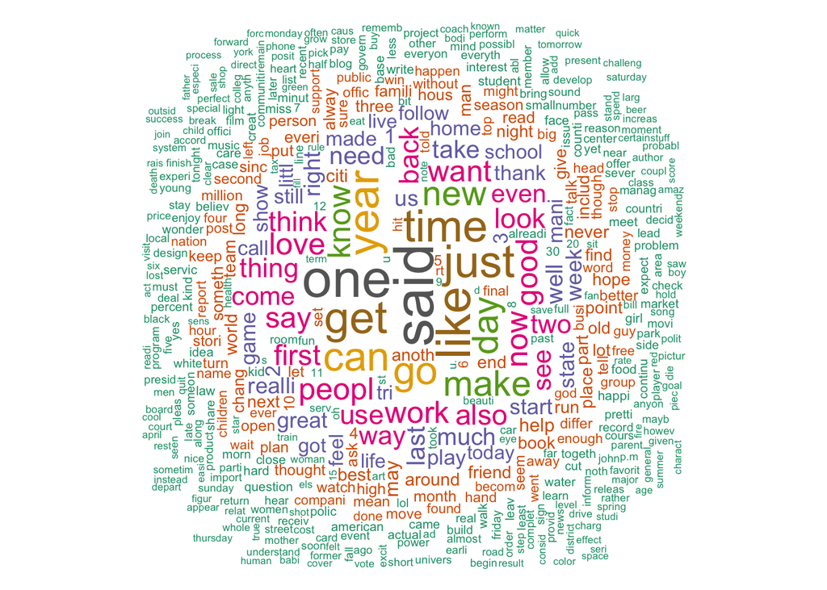

### Conclusion

These are three very different data sets and should be treated as such. The twitter data set will be more adventurous becuase it uses more words than there are in the already defined dictionary.

Thanks for the review